## Executive Summary

In this report we analyze the data set of mtcars in R to establish a regression model with the outcome as mile per gallon (**mpg**). Then we try to answer the question that whether automatic or manual transmission is better for MPG. According to our analysis, we find that with over 99% confidence, automatic transmission has a higher mean for MPG than manual transmission. In the model we established, we find more quantitative results regarding mpg differences bewteen these two car models.

## Data Set Introduction

The data set was extracted from the 1974 Motor Trend US magazine, and comprises fuel consumption and 10 aspects of automobile design and performance for 32 automobiles (1973–74 models). Our purpose of this analysis is to fit a regression model with mpg as the outcome. Trying to find the miles per gallon (**mpg** variable in the data set) difference between automatic and manual cars (factor variable **am** in the data set) is also a goal for our analysis.

## Exploratory Analysis

From an easy exploratory analysis we find a superior efficiency of automatic cars over manual cars, from both the data and box plots (see Figure 1 & 2 in the appendix). To be more detailed, manual cars have a mean efficiency of 17.15, with standard error of 3.83 miles per gallon while automatic models have a mean of 24.4 ± 6.17. We then do a t-test to reject the hypothesis that both car models have the same efficiency in mpg. The test rejects the hypothesis with a 99% confidence.

## Regression Models Selection

We start with only the **am** variable, since we need to study its relation with the **mpg** variable. Then we include all the other variables and interaction terms with the factor **am**.

```r
fit <- lm(mpg~as.factor(am) *., data = mtcars)
summary(fit)
```

Then we choose variables that are significant in the model, which are **as.factor(am)**, **as.factor(am):wt**, **as.factor(am):qsec** and **as.factor(am):carb** and do a nested model test.

```r
fit1 <- lm(mpg ~ as.factor(am), data = mtcars)
fit2 <- update(fit, mpg~ as.factor(am):wt)
fit3 <- update(fit, mpg~ as.factor(am):(wt + qsec))
fit4 <- update(fit, mpg~ as.factor(am):(wt + qsec + carb))
anova(fit1, fit2, fit3, fit4)
```

```
## Analysis of Variance Table
##
## Model 1: mpg ~ as.factor(am)
## Model 2: mpg ~ as.factor(am):wt
## Model 3: mpg ~ as.factor(am):wt + as.factor(am):qsec
## Model 4: mpg ~ as.factor(am):wt + as.factor(am):qsec + as.factor(am):carb
##   Res.Df    RSS Df Sum of Sq       F    Pr(>F)
## 1     30 720.90
## 2     29 269.76  1    451.14 102.087 2.602e-10 ***
## 3     27 118.70  2    151.06  17.091 2.098e-05 ***
## 4     25 110.48  2      8.22   0.930    0.4078
## ---
## Signif. codes:  0 '***' 0.001 '**' 0.01 '*' 0.05 '.' 0.1 ' ' 1
```

From the result, fit3 with formula: mpg ~ as.factor(am):(wt + qsec) is the best model among these four models. We do the regression and see the results for coefficients and residuals.

```r
summary(fit3)
```

```
##
## Call:
## lm(formula = mpg ~ as.factor(am):wt + as.factor(am):qsec, data = mtcars)
##
## Residuals:
##     Min      1Q  Median      3Q     Max
## -3.9361 -1.4017 -0.1551  1.2695  3.8862
##
## Coefficients:
##                     Estimate Std. Error t value Pr(>|t|)
## (Intercept)          13.9692     5.7756   2.419  0.02259 *
## as.factor(am)0:wt    -3.1759     0.6362  -4.992 3.11e-05 ***
## as.factor(am)1:wt    -6.0992     0.9685  -6.297 9.70e-07 ***
## as.factor(am)0:qsec   0.8338     0.2602   3.205  0.00346 **
## as.factor(am)1:qsec   1.4464     0.2692   5.373 1.12e-05 ***
## ---
## Signif. codes:  0 '***' 0.001 '**' 0.01 '*' 0.05 '.' 0.1 ' ' 1
##
## Residual standard error: 2.097 on 27 degrees of freedom
## Multiple R-squared:  0.8946, Adjusted R-squared:  0.879
## F-statistic: 57.28 on 4 and 27 DF,  p-value: 8.424e-13
```

Compared the adjusted R squared between fit3 and fit (0.879 and 0.903), this could be the model we use to do analysis between **mpg** and **am**. A plot for residuals is shown in Figure 3 in the appendix. From the plot we can see that the model fits well with few outliers.

**Analysis of the model**: If we hold the qsec constant at its mean, for each unit increase in the weight starting at mean, miles per galon will decrease -3.176 for manual cars and -6.1 for automatic cars. These coefficients are quite significant in the model with low standard errors. On the other hand, if we hold the weight constant at its mean, for each unit increase in the qsec starting at mean value, manual cars will make 0.834 more miles per gallon while 1.446 for automatic cars.

## Appendix

### Data Set Introduction

```r
# Load all packages we need for this analysis.
library(MASS)

# Read and take a quick look at the data.
data(mtcars)
str(mtcars)
```

```
## 'data.frame':    32 obs. of  11 variables:
##  $ mpg : num  21 21 22.8 21.4 18.7 18.1 14.3 24.4 22.8 19.2 ...
##  $ cyl : num  6 6 4 6 8 6 8 4 4 6 ...
##  $ disp: num  160 160 108 258 360 ...
##  $ hp  : num  110 110 93 110 175 105 245 62 95 123 ...
##  $ drat: num  3.9 3.9 3.85 3.08 3.15 2.76 3.21 3.69 3.92 3.92 ...
##  $ wt  : num  2.62 2.88 2.32 3.21 3.44 ...
##  $ qsec: num  16.5 17 18.6 19.4 17 ...
##  $ vs  : num  0 0 1 1 0 1 0 1 1 1 ...
##  $ am  : num  1 1 1 0 0 0 0 0 0 0 ...
##  $ gear: num  4 4 4 3 3 3 3 4 4 4 ...
##  $ carb: num  4 4 1 1 2 1 4 2 2 4 ...
```

### Exploratory Analysis

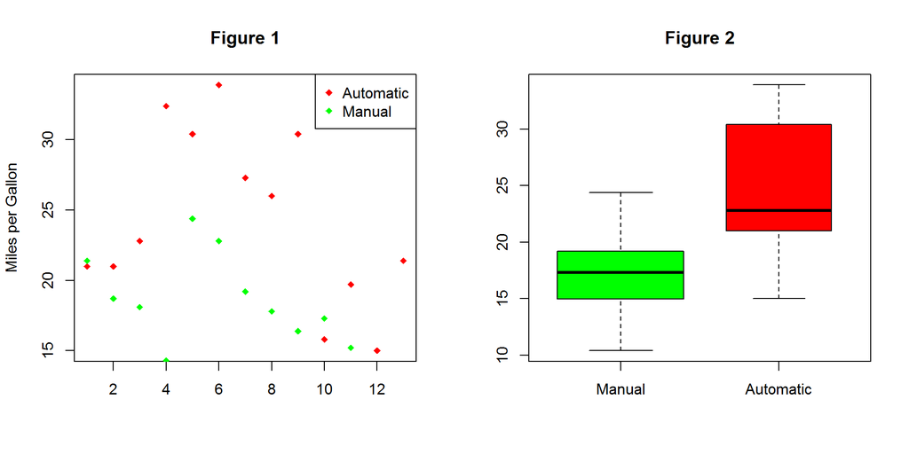

```r
# Extract the data we need
automatic = mtcars[mtcars$am == 1, ]$mpg
manual = mtcars[mtcars$am == 0, ]$mpg

# Plot the graphs
par(mfrow = c(1,2))
plot(automatic, col="red", pch=18, main = "Figure 1", xlab = "", ylab = "Miles per Gallon")
points(manual, col="green", pch=18)
legend("topright",c("Automatic", "Manual"), pch = c(18, 18), col = c("red", "green"))

boxplot(mpg~am,data=mtcars,main="Figure 2",varwidth=TRUE, col=c("green","red"), names=c("Manual","Automatic"))
```

```r
# Do the t-test for difference between means
t.test(automatic, manual, alternative="two.sided")
```

```
##
##  Welch Two Sample t-test
##
## data:  automatic and manual
## t = 3.7671, df = 18.332, p-value = 0.001374
## alternative hypothesis: true difference in means is not equal to 0
## 95 percent confidence interval:
##   3.209684 11.280194
## sample estimates:
## mean of x mean of y
##  24.39231  17.14737
```

### Regression Models Selection

```r
# Include all variables and interaction terms with am
fit <- lm(mpg~as.factor(am) *., data = mtcars)
summary(fit)
```

```
##
## Call:
## lm(formula = mpg ~ as.factor(am) * ., data = mtcars)
##
## Residuals:
##     Min      1Q  Median      3Q     Max
## -2.0346 -0.7600  0.1089  0.5484  2.6959
##
## Coefficients: (2 not defined because of singularities)
##                       Estimate Std. Error t value Pr(>|t|)
## (Intercept)            8.64345   22.37276   0.386   0.7060
## as.factor(am)1      -146.55089   66.32350  -2.210   0.0473 *
## cyl                   -0.53391    1.17256  -0.455   0.6570
## disp                  -0.02025    0.01813  -1.117   0.2859
## hp                     0.06223    0.04791   1.299   0.2184
## drat                   0.59159    3.13258   0.189   0.8534
## wt                     1.95413    2.32068   0.842   0.4162
## qsec                  -0.88432    0.78877  -1.121   0.2842
## vs                     0.73891    2.61246   0.283   0.7821
## am                          NA         NA      NA       NA
## gear                   8.65416    4.05167   2.136   0.0540 .
## carb                  -4.81050    1.97648  -2.434   0.0315 *
## as.factor(am)1:cyl    -0.74737    4.26142  -0.175   0.8637
## as.factor(am)1:disp    0.20017    0.15960   1.254   0.2337
## as.factor(am)1:hp     -0.22268    0.13808  -1.613   0.1328
## as.factor(am)1:drat   -5.54142    5.84742  -0.948   0.3620
## as.factor(am)1:wt    -12.49602    5.07276  -2.463   0.0299 *
## as.factor(am)1:qsec    8.97928    3.21468   2.793   0.0162 *
## as.factor(am)1:vs      0.20419    5.28538   0.039   0.9698
## as.factor(am)1:am           NA         NA      NA       NA
## as.factor(am)1:gear    3.67430    7.25129   0.507   0.6215
## as.factor(am)1:carb    9.49905    4.16833   2.279   0.0418 *
## ---
## Signif. codes:  0 '***' 0.001 '**' 0.01 '*' 0.05 '.' 0.1 ' ' 1
##
## Residual standard error: 1.877 on 12 degrees of freedom
## Multiple R-squared:  0.9625, Adjusted R-squared:  0.9031
## F-statistic:  16.2 on 19 and 12 DF,  p-value: 8.251e-06
```

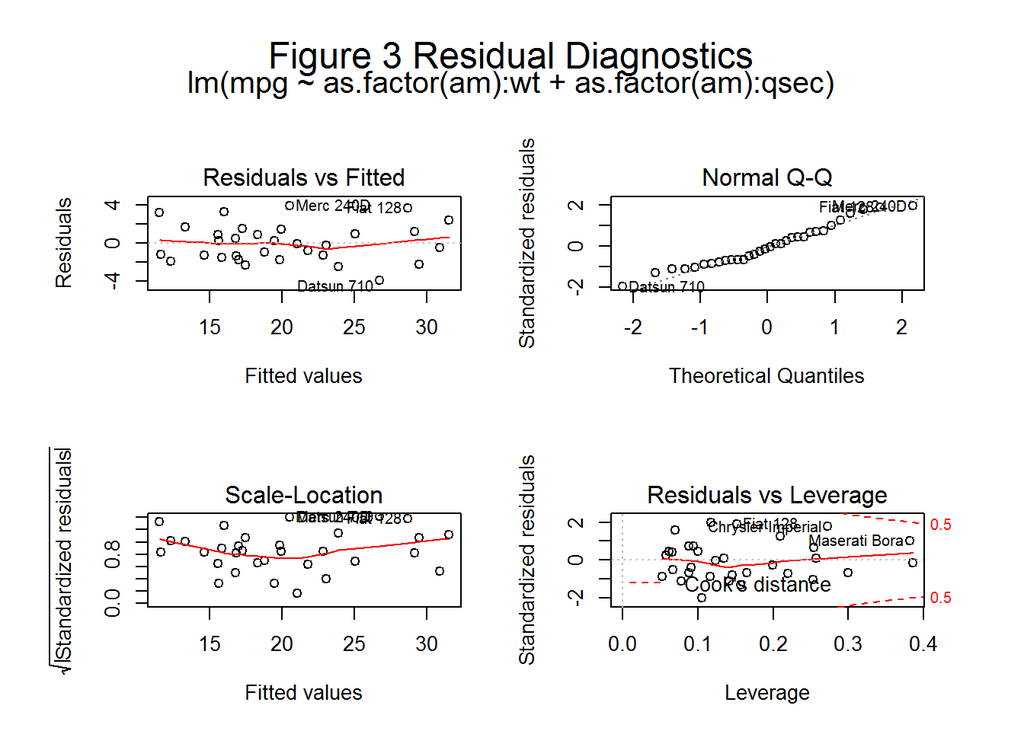

```r
# Plot residuals of the final model.
par(mfrow = c(2,2), oma = c(0,2,4,2))
plot(fit3)
mtext("Figure 3 Residual Diagnostics", cex = 1.5, outer = TRUE, line = 1)
```